# R Notebook

# 8. ggplot2

we will be creating pots using the ggplot2 package

```r
library(dplyr)
library(ggplot2)
```

There are other packages ; such as grid, lattice. ggpolot2: breaks plots into components in a way that permits beginners to create complex & aesthetic plots

*good!*

reason 1. it is more intuitive because it uses a grammar of graphics ‘gg’ by learning ggplot2 building blocks and grammar - create diff. plots

reason 2. default behavior is chosen to satisfy majority of cases and is visually pleasing

*limitation*

1. designed to work with ‘tidy’ data tables. but we can just convert into this format :d

https://www.rstudio.com/wp-content/uploads/2015/03/ggplot2-cheatsheet.pdf

# 8.1 The components of a graph

The first step in learning ggplot2: to be able to break a graph apart into components Main three components: **Data** **Geometry**: scatterplot, barplot, histogram, smooth densities, qqplot, boxplot, etc. **Aesthetic mapping**: uses visual cues to represent the information. x-axis, y-axis. color.

```r
library(dslabs)
data(murders)
```

# 8.2 ggplot objects

function ‘ggplot’: initializes the graph first argument; used to specify what data is associated

```r
ggplot(data=murders)
```

or

```r
murders %>% ggplot()
```

blacnk: no geometry defined

```r
p <- ggplot(data = murders)
class(p)
```

```
[1] "gg"     "ggplot"
```

to render the plot associated,

```r
print(p)
```

```r
p
```

# 8.3 Geometries

We create graphs by adding *layers*. Layers : define geometries, compute summary statistics, define scales, change styles. we use ‘+’ to add layers

```r
DATA %>% ggplot() + LAYER 1 + LAYER 2 + … + LAYER N
```

the first added layer defines the geometry function used to create scatterplot : ‘geom_point’

Geometry function names follow the pattern: geom_X (X = name of the geometry)

to find out what mappings are expected ; we read **Aesthetics** section of the help file:

> Aesthetics

> geom_point understands the following aesthetics (required aesthetics are in bold):

> x

> y

> alpha

> colour

at least two arguments required : x and y

# 8.4 Aesthetic mappings

describe how data connect with graph; distance along axis, size or color

function ‘aes’ connects data with what we see on the graph, often used as the argument of a geometry fuction

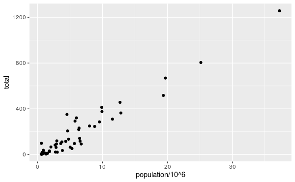

```r
# total murders versus population in millions, scatterplot

murders %>% ggplot() +
  geom_point(aes(x = population/10^6, y = total))
```

We can drop ‘x=’ and ‘y=’ if we wanted to we can also add a layer to the p object that was defined above

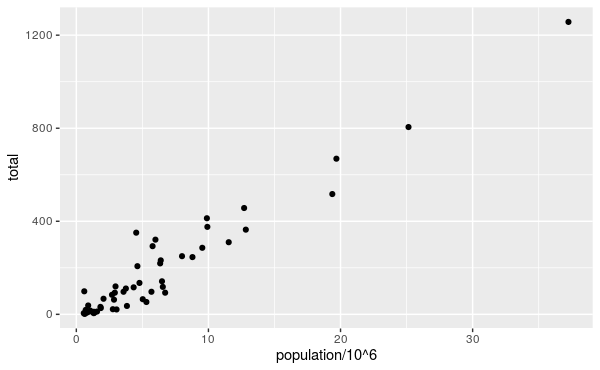

```r
p + geom_point(aes(population/10^6, total))
```

scale and labels are defined by default ‘aes’ also uses variable names from the object component

# 8.5 Layers

A second layer in the plot involves adding a label function ‘geom_label’, ‘geom_text’: add text to the plot with and without a rectangle behind the text

each pointhas a label: we need aesthetic mapping to make the connectino between points and labels

we supply the mapping between point and label through the ‘label’ argument of ‘aes’.

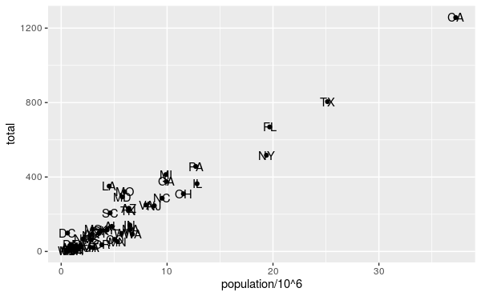

```r
p + geom_point(aes(population/10^6, total)) +
  geom_text(aes(population/10^6, total, label = abb))
```

we added a second layer!

this call is fine

```r
p_test <- p + geom_text(aes(population/10^6, total, label = abb))
```

whereas this call

```r
p_test <- p + geom_text(aes(population/10^6, total), label = abb)
```

```
Error in layer(data = data, mapping = mapping, stat = stat, geom = GeomText,  :
  object 'abb' not found
```

gives error since ‘abb’ not found

# 8.5.1 Tinkering with arguments

‘size’ is an aesthetic and we can change

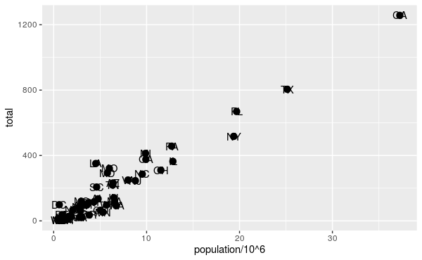

```r
p + geom_point(aes(population/10^6, total), size = 3) +
  geom_text(aes(population/10^6, total, label = abb))
```

‘size’ is **not** a mapping, whereas mapping need to be inside aes()

affect points -> don’t need to be included inside ‘aes’

points are larger, so hard to see the labels argument ‘nudge_x’: moves the text slightly to the right or to the left

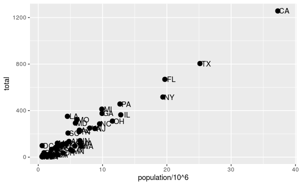

```r
p + geom_point(aes(population/10^6, total), size = 3) +
  geom_text(aes(population/10^6, total, label = abb), nudge_x = 1)
```

# 8.6 Global versus local aesthetic mappings

we can use *a global aesthetic mapping* to avoid defining the mapping twice can do this when defining blank state ‘ggplot’ object

```r
args(ggplot)
```

```
function (data = NULL, mapping = aes(), ..., environment = parent.frame())
NULL
```

if we define a mapping in ‘ggplot’, all the geometires that are added as layers will default

```r
p <- murders %>% ggplot(aes(population/10^6, total, label = abb))
```

the code becomes simple

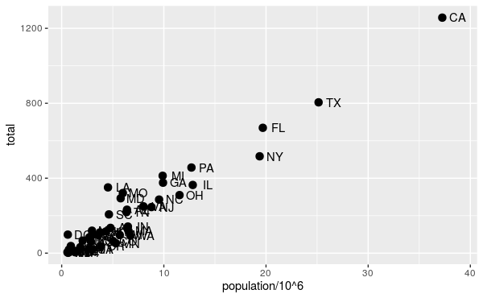

```r
p + geom_point(size = 3) +
  geom_text(nudge_x = 1.5)
```

we keep ‘size’ and ‘nudge_x’ arguments in ‘geom_point’ and ‘geom_text’ respectively. If we put those arguments in ‘aes’ then they would apply to both points and labels

‘geom_point’ function does not need a ‘label’ argument and ignores the aesthetic

we can override global mapping by defining a new mapping within each layer : ‘local’ definitions

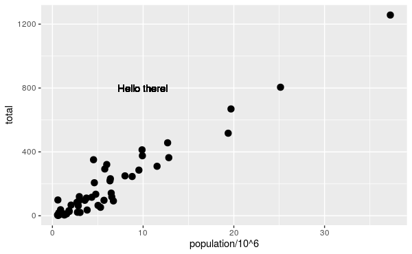

```r
p + geom_point(size = 3) +
  geom_text(aes(x = 10, y = 800, label = "Hello there!"))
```

# 8.7 Scales

Our desired scales are in log-scale, which is not the default ‘scale_x_continuous’ function lets us control the behavior of scales

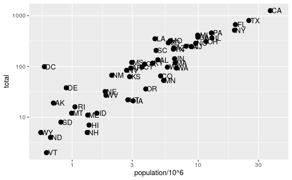

```r
p + geom_point(size = 3) +
  geom_text(nudge_x = 0.05) +
  scale_x_continuous(trans = "log10") +
  scale_y_continuous(trans = "log10")
```

*nudge* must be made smaller cuz we are i the log-scale now

ggplot2 provides ‘scale_x_log10’ and ‘scale_y_log10’

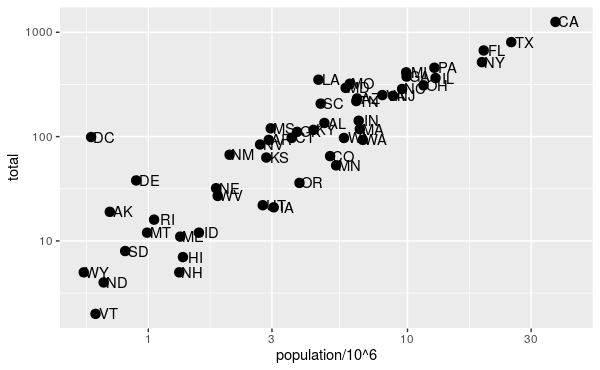

```r
p + geom_point(size = 3) +
  geom_text(nudge_x = 0.05) +
  scale_x_log10() +
  scale_y_log10()
```

# 8.8 Labels and Titles

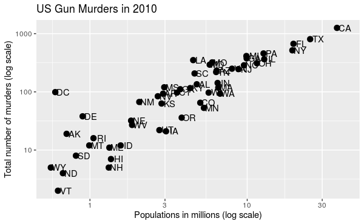

```r
p + geom_point(size = 3) +
  geom_text(nudge_x = 0.05) +
  scale_x_log10() +
  scale_y_log10() +
  xlab("Populations in millions (log scale)") +
  ylab("Total number of murders (log scale)") +
  ggtitle("US Gun Murders in 2010")
```

xlab, ylab, ggtitle -> for titles

# 8.9 Categories as colors

we can change color of points using ‘col’ argument in the ‘geom_point’ function.

```r
p <-  murders %>% ggplot(aes(population/10^6, total, label = abb)) +
  geom_text(nudge_x = 0.05) +
  scale_x_log10() +
  scale_y_log10() +
  xlab("Populations in millions (log scale)") +
  ylab("Total number of murders (log scale)") +
  ggtitle("US Gun Murders in 2010")
```

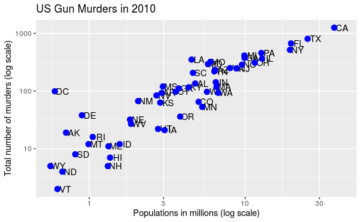

```r
p + geom_point(size=3, color="blue")
```

we want to assign color depending on the geographical region

if we assign a categorical variable to color, it automatically assigns a different color to each category, and adds a legend

this is an aesthetic mapping, and use ‘aes’

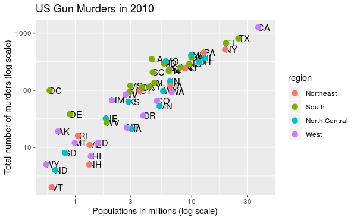

```r
p + geom_point(aes(col=region), size = 3)
```

‘x’ and ‘y’ mappings are from those already defined i ‘p’ we also move ‘aes’ to the first argument; where mappings are expected in this function call

ggplo2 automatically adds a legend that maps color to region to avoid this, we use arguent show.legend = FALSE’

# 8.10 Annotation, Shapes, and adjustments

we often want to add shapes or annotation to figures that are not derived directly from the aesthetic mapping

we want to add a line ; average murder rate for the entire country

we define per million rate to be r, this line is defined by the formula: y=rx, with ‘y’ = total murders, ‘x’ = population in millions

in the log scale, log(y) = log(r) + log(x)

In our plot it’s a line with slope 1 and intercept log(r)

```r
r <- murders %>%
  summarize(rate = sum(total) /  sum(population) * 10^6) %>%
  pull(rate)
```

to add a line, we use the ‘geom_abline’ ggplot2 uses ‘ab’ in the name to remind us we are supplying the intercept (a) and slope (b)

default: slope 1, intercept 0

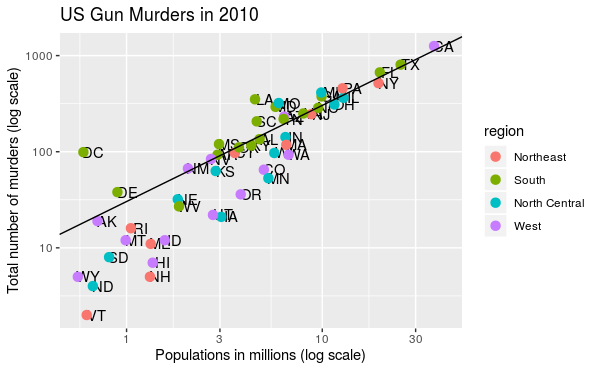

```r
p + geom_point(aes(col=region), size = 3) +
  geom_abline(intercept = log10(r))
```

here ‘geom_abline’ does not use any information from the data object

we can change the line type and color of the lines using arguments. also we draw it first ; it doesn’t go over our points

```r
p <- p + geom_abline(intercept = log10(r), lty = 2, color = "darkgrey") +
  geom_point(aes(col=region), size = 3)
```

we have redefined p and used this new p below and in the next section

we frequently need to make minor tweaks to the default we can make changes to the legend via the function ‘scale_color_discrete’

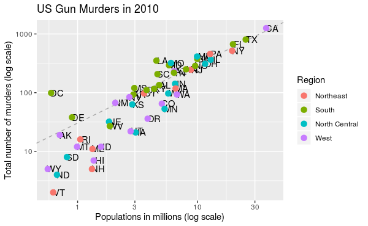

```r
p <- p + scale_color_discrete(name = "Region")
p
```

# 8.11 Add-on packages

ggthemes’ and ‘ggrepel’ packages

the style of graph can be changed using the ‘theme’ functions

several themes are included

function in dslabs package ; automatically sets a default theme

```r
ds_theme_set()
```

many other themes are added by the package ‘ggthemes’

among those are the ‘theme_economist’ themes that we used

```r
install.packages('ggthemes')
```

```
Error in install.packages : Updating loaded packages
```

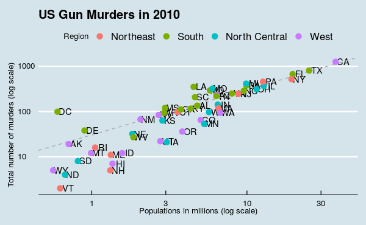

```r
library(ggthemes)
p+theme_economist()
```

you might try the theme_fivethirtyeight() theme instead

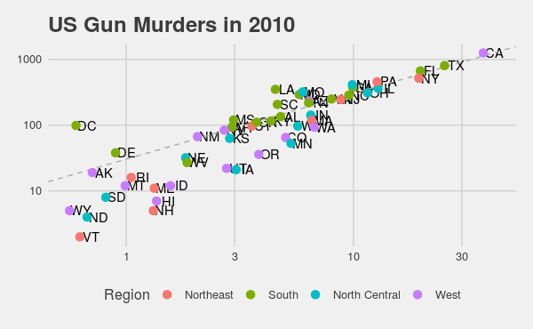

```r
p+ theme_fivethirtyeight()
```

OOHHHHH

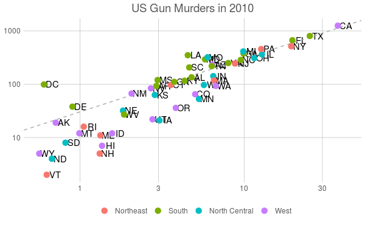

```r
p + theme_excel_new()
```

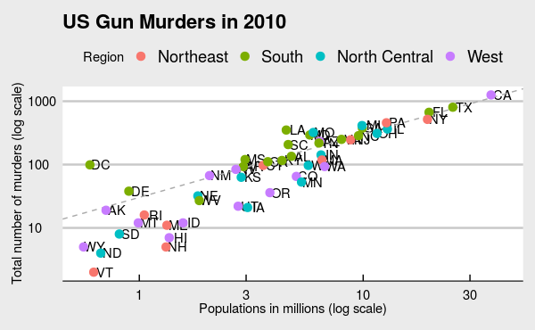

```r
p+theme_economist_white()
```

the final difference has to do with the position of the labels ; some of the labels fall on top of each other

add-on package ‘ggrepel’ includes a geometry that adds labels, ensuring that they don’t fall on top of each other. we change ‘geom_text’ with ‘geom_text’repel’

# 8.12 Putting it all together

```r
install.packages("ggrepel")
```

```
Error in install.packages : Updating loaded packages
```

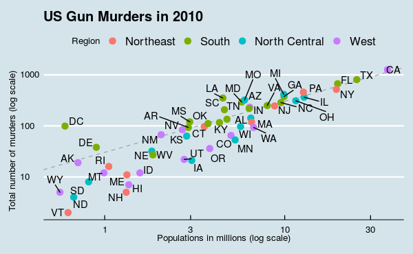

```r
library(ggthemes)
library(ggrepel)

r <- murders %>%
  summarize(rate = sum(total) /  sum(population) * 10^6) %>%
  pull(rate)

murders %>% ggplot(aes(population/10^6, total, label = abb)) +
  geom_abline(intercept = log10(r), lty = 2, color = "darkgrey") +
  geom_point(aes(col=region), size = 3) +
  geom_text_repel() +
  scale_x_log10() +
  scale_y_log10() +
  xlab("Populations in millions (log scale)") +
  ylab("Total number of murders (log scale)") +
  ggtitle("US Gun Murders in 2010") +
  scale_color_discrete(name = "Region") +
  theme_economist()
```

# 8.13 Quick plots with ‘qplot’

there are instances in which all we want is to make a quick plot if we want to keep consistent with ggplot style(not using hist, plot and boxplot) we can use the functino ‘qplot’

```r
# values in two vectors
data(murders)
x <- log10(murders$population)
y <- murders$total
```

we want to make scatterplot with ggplot

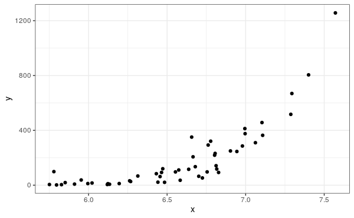

```r
data.frame(x = x, y = y) %>%
  ggplot(aes(x, y)) +
  geom_point()
```

seems like too much code! ‘qplot’ function allows us to generate a plot quickly

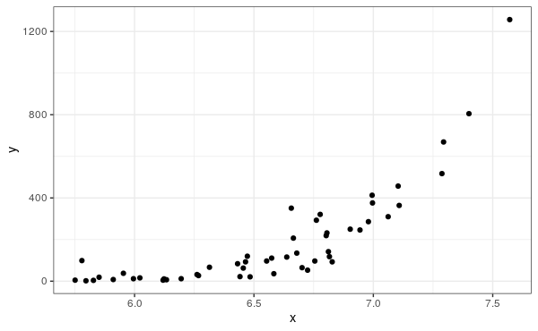

```r
qplot(x, y)
```

# 8.1 Grids of plots

there are reasons to graph plots next to each other ; ‘gridextra’ package

```r
install.packages("gridExtra")
```

```
Error in install.packages : Updating loaded packages
```

```r
library(gridExtra)
```

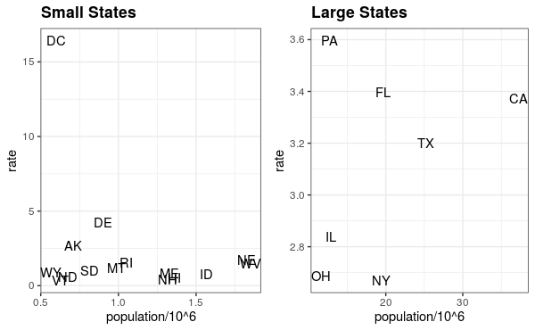

```r
p1 <- murders %>%
  mutate(rate = total/population*10^5) %>%
  filter(population < 2*10^6) %>%
  ggplot(aes(population/10^6, rate, label = abb)) +
  geom_text() +
  ggtitle("Small States")

p2 <- murders %>%
  mutate(rate = total/population*10^5) %>%
  filter(population > 10*10^6) %>%
  ggplot(aes(population/10^6, rate, label = abb)) +
  geom_text() +
  ggtitle("Large States")

grid.arrange(p1, p2, ncol = 2)
```

# 8.15 Exercises

start by loading the dplyr and ggplot2 library as well as the murders and heights data

```r
library(dplyr)
library(ggplot2)
library(dslabs)
data(heights)
data(murders)
```

1. With ggplot2 plots can be saved as objects. For example we can associate a dataset with a plot object like this

```r
p <- ggplot(data = murders)
```

and we can also use the pipe:

```r
p <- murders %>% ggplot()
```

what is the class of the object p?

```r
class(p)
```

```
[1] "gg"     "ggplot"
```

**ggplot**

2. Remember that to print an object you can use the command print or simply type the object. For example

```r
x<-2
x
```

```
[1] 2
```

```r
print(x)
```

```
[1] 2
```

Print the object p defined in exercise one and describe what you see.

A. Nothing happens.

**B. A blank slate plot.**

C. A scatter plot.

D. A histogram.

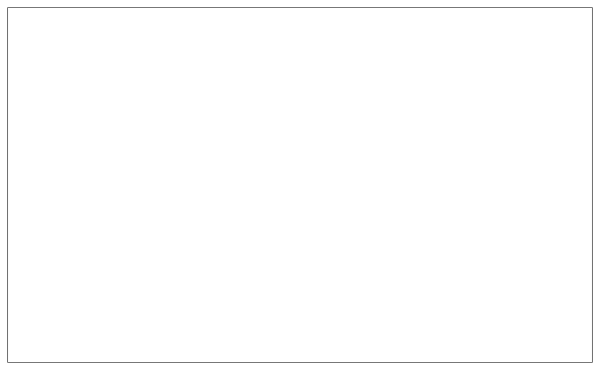

```r
p
```

3. Using the pipe %>%, create an object p but this time associated with the heights dataset instead of the murders dataset.

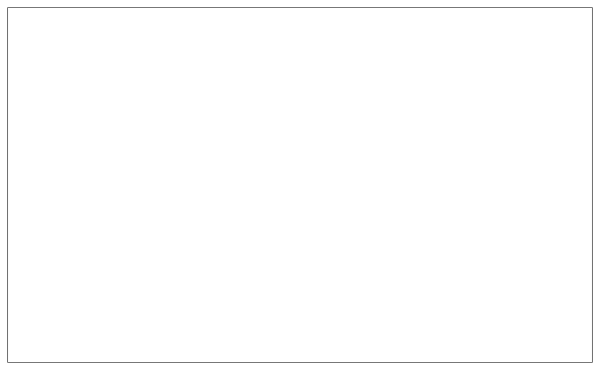

```r
p <- heights %>% ggplot()
p
```

4. What is the class of the object p you have just created?

```r
class(p)
```

```
[1] "gg"     "ggplot"
```

**ggplot**

5. Now we are going to add a layers and the corresponding aesthetic mappings. For the murders data we plotted total murders versus population sizes. Explore the murders data frame to remind yourself what are the names for these two variables and select the correct answer. Hint: Look at ?murders.

A. state and abb.

B. total_murders and population_size.

**C. total and population.**

D. murders and size.

```r
names(murders)
```

```
[1] "state"      "abb"        "region"     "population" "total"
```

6. To create the scatterplot we add a layer with geom_point. The aesthetic mappings require us to define the x-axis and y-axis variables respectively. So the code looks like this:

```r
murders %>% ggplot(aes(x = , y = )) +
  geom_point()
```

```
Error: geom_point requires the following missing aesthetics: x, y
```

except we have to define the two variables x and y. Fill this out with the correct variable names.

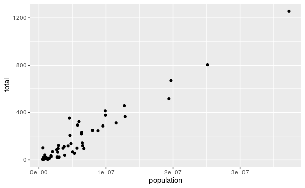

```r
murders %>% ggplot(aes(x = population, y = total)) +
  geom_point()
```

7. Note that if we don’t use argument names, we can obtain the same plot by making sure we enter the variable names in the right order like this:

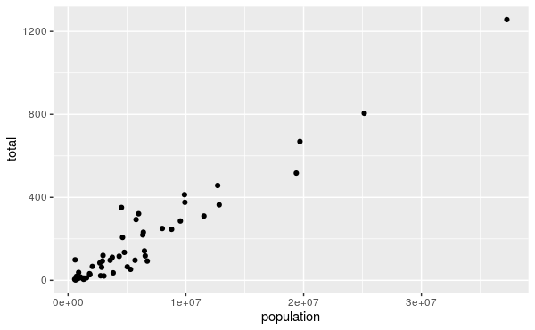

```r
murders %>% ggplot(aes(population, total)) +
  geom_point()
```

8. If instead of points we want to add text, we can use the geom_text() or geom_label() geometries. The following code

```r
murders %>% ggplot(aes(population, total)) +
  geom_label()
```

```
Error: geom_label requires the following missing aesthetics: label
```

will give us the error message: Error: geom_label requires the following missing aesthetics: label

Why is this?

**A. We need to map a character to each point through the label argument in aes.**

B. We need to let geom_label know what character to use in the plot.

C. The geom_label geometry does not require x-axis and y-axis values.

D. geom_label is not a ggplot2 command.

9. Rewrite the code above to abbreviation as the label through aes

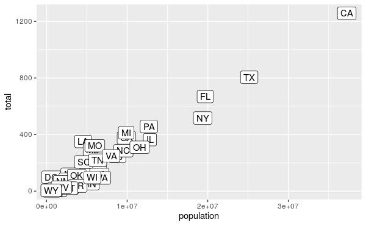

```r
murders %>% ggplot(aes(population, total, label=abb)) +  geom_label()
```

10. Change the color of the labels through blue. How will we do this?

A. Adding a column called blue to murders

B. Because each label needs a different color we map the colors through aes

C. Use the color argument in ggplot

**D. Because we want all colors to be blue, we do not need to map colors, just use the color argument in geom_label**

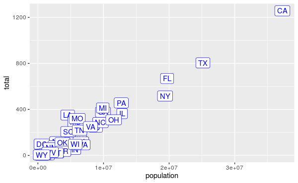

```r
murders %>% ggplot(aes(population, total, label=abb)) +  geom_label(color="blue")
```

12. Now suppose we want to use color to represent the different regions. In this case which of the following is most appropriate:

A. Adding a column called color to murders with the color we want to use.

**B. Because each label needs a different color we map the colors through the color argument of aes.**

C. Use the color argument in ggplot.

D. Because we want all colors to be blue, we do not need to map colors, just use the color argument in geom_label.

13. Rewrite the code above to make the labels’ color be determined by the state’s region.

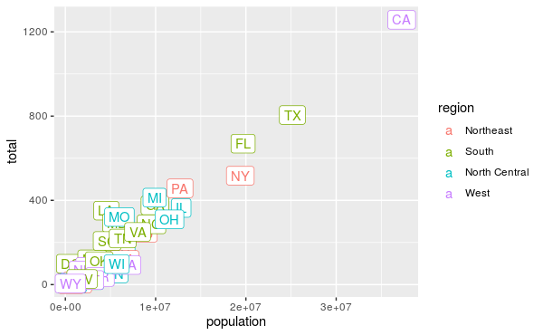

```r
murders %>% ggplot(aes(population, total, label=abb, col=region)) +  geom_label()
```

14. Now we are going to change the x-axis to a log scale to account for the fact the distribution of population is skewed. Let’s start by define an object p holding the plot we have made up to now

```r
p <- murders %>%
  ggplot(aes(population, total, label = abb, color = region)) +
  geom_label()
```

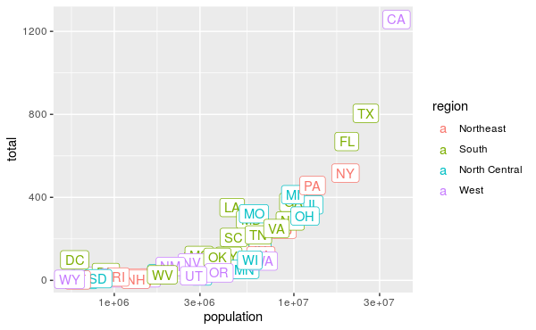

```r
p + scale_x_log10()
```

15. Repeat the previous exercise but now change both axes to be in the log scale.

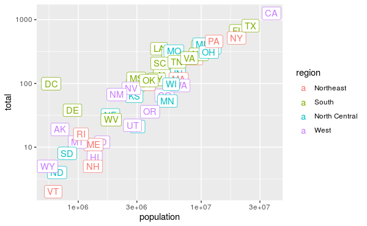

```r
p + scale_x_log10() + scale_y_log10()
```

16. Now edit the code above to add the title ‘Gun Murder Data’ to the plot. Hint: use the ggtitle function

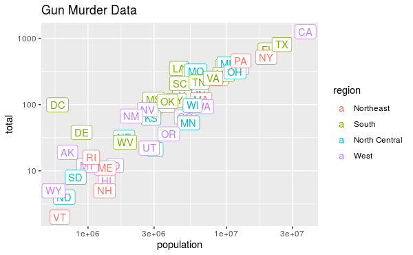

```r
p + scale_x_log10() + scale_y_log10() + ggtitle("Gun Murder Data")
```